# Project2

Yuzhi Li, Katelyn Settlemyre

2022-10-03

This vignette explains how to contact an API, demonstrated with the [Spoonacular Food API](https://spoonacular.com/food-api). We will create functions to interact with the API and return data.

### Example of R code that Can Contact the Food API by Search Criteria

First, we’ll show an example of how to contact the API using the complex recipe search:

```r
res<-GET("https://api.spoonacular.com/recipes/complexSearch?query=chicken&maxFat=60&number=5&apiKey=be3c2a74ce6c4f0c83b254b34ceca7f5")
dat<-fromJSON(res$url)
as.data.frame(dat)
```

```
## # A tibble: 5 × 8
##   results.id results.title   results.image resul…¹ resul…² offset number total…³
##        <int> <chr>           <chr>         <chr>   <list>   <int>  <int>   <int>
## 1     637876 Chicken 65      https://spoo… jpg     <df>         0      5     577
## 2     716342 Chicken Suya    https://spoo… jpg     <df>         0      5     577
## 3     638420 Chicken Wings   https://spoo… jpg     <df>         0      5     577
## 4     638174 Chicken Lo Mein https://spoo… jpg     <df>         0      5     577
## 5     638086 Chicken Fingers https://spoo… jpg     <df>         0      5     577
## # … with abbreviated variable names ¹results.imageType,
## #   ²results.nutrition$nutrients, ³totalResults
```

However, new searches are tedious to type out each time! We will create functions to interact with the API to retrieve data.

# Package Requirements

Here, we list the packages required to interact with the API and use the functions defined in this vignette.  
- `httr` - used to access the API  
- `jsonlite` - used to convert the data from the API into a data frame  
- `tidyverse` - used for data manipulation and graphing

# API Interaction Functions

To use some of the interaction functions in this section, you will need to have a key to access the API. You can register for free [here](https://spoonacular.com/food-api/console#Dashboard) if you do not already have a key for this API.

## `recipe.search`

This function allows you to search for recipes given query (i.e., what are you looking for?), [diet type](https://spoonacular.com/food-api/docs#Diets), [type of dish](https://spoonacular.com/food-api/docs#Meal-Types) (such as breakfast, dessert, side dish, etc.), the maximum number of carbs (in grams), the minimum amount of protein (in grams), and the maximum amount of fat (in grams). To give more than one option for a given input, you will need to give a string of comma separated values.

```r
recipe.search<- function(key=NULL, query=NULL, diet=NULL, type=NULL, maxCarbs=NULL, minProtein=NULL, maxFat=NULL){
  if(is.null(key)){
    return("your API Key is required.")
  }
  basic.url<-"https://api.spoonacular.com/recipes/complexSearch"
  search.opt<-list(query=query, diet=diet, type=type, maxCarbs=maxCarbs, minProtein=minProtein, maxFat=maxFat, apiKey=key, NULL)
  search.opt2<-search.opt[-which(sapply(search.opt, is.null))]
  #remove spaces from user input
  for(i in 1:length(search.opt2)){
    search.opt2[i]<-str_remove_all(search.opt2[i], " ")
  }
  res<-paste0(basic.url,"?")
  for(i in 1:length(search.opt2)){
    res<-paste0(res,"&", names(search.opt2[i]), "=", search.opt2[i])
  }
  res <- str_remove(res, "&")    #remove the first &, unnecessary

  data<-httr::GET(res)
  mydf<- jsonlite::fromJSON(data$url)
  result<-as.data.frame(mydf)
      return(result)
    }
```

Search recipe example by using the function above:

```r
recipe.search(key="be3c2a74ce6c4f0c83b254b34ceca7f5", query="chicken", maxFat=60)
```

```
## # A tibble: 10 × 8
##    results.id results.title     results.…¹ resul…² resul…³ offset number total…⁴
##         <int> <chr>             <chr>      <chr>   <list>   <int>  <int>   <int>
##  1     637876 Chicken 65        https://s… jpg     <df>         0     10     577
##  2     716342 Chicken Suya      https://s… jpg     <df>         0     10     577
##  3     638420 Chicken Wings     https://s… jpg     <df>         0     10     577
##  4     638174 Chicken Lo Mein   https://s… jpg     <df>         0     10     577
##  5     638086 Chicken Fingers   https://s… jpg     <df>         0     10     577
##  6     638125 Chicken In A Pot  https://s… jpg     <df>         0     10     577
##  7     637999 Chicken Burritos  https://s… jpg     <df>         0     10     577
##  8     638257 Chicken Porridge  https://s… jpg     <df>         0     10     577
##  9     667707 chicken marbella  https://s… jpg     <df>         0     10     577
## 10     638148 Chicken Kale Bake https://s… jpg     <df>         0     10     577
## # … with abbreviated variable names ¹results.image, ²results.imageType,
## #   ³results.nutrition$nutrients, ⁴totalResults
```

## `random.recipes`

With this function, you can get between 1 and 100 random recipes. You may also include tags by giving a string of comma separated values.

```r
#gives 1-100 random recipes
random.recipes <- function(apiKey=NULL, number=NULL, tags=NULL){
  if(is.null(apiKey)){
    return("Please enter your API key.")
  }

  input <- list(apiKey=apiKey, number=number, tags=tags, NULL)   #null list item to use all options
  opts <- input[-which(sapply(input, is.null))]
  #remove spaces from user input
  for(i in 1:length(opts)){
    opts[i]<-str_remove_all(opts[i], " ")
  }
  #cerate URL
  link <- "https://api.spoonacular.com/recipes/random?"
  for(i in 1:length(opts)){
    link<-paste0(link,"&", names(opts[i]), "=", opts[i])
  }
  link <- str_remove(link, "&")    #remove the first &

  dat <- httr::GET(link)
  df<- jsonlite::fromJSON(dat$url)
  results <- as.data.frame(df)
  return(results)
}
```

We show an example of this function here.

```r
random.recipes(apiKey = "31bf40952ec14026b2f82b5055fdab93", number=20, tags = "carrots, potatoes")
```

[output not shown]

## `diet.restrictions`

For people with dietary restrictions, intolerances, or sensitivities, this function allows you to specify [diet](https://spoonacular.com/food-api/docs#Diets) and food [intolerances](https://spoonacular.com/food-api/docs#Intolerances). It also allows for ingredients to be excluded or included. To give more than one option for a given input, you will need to give a string of comma separated values.

```r
#function to search for recipes given diet type, food intolerances, excluded ingredients
diet.restrictions <- function(apiKey=NULL, query=NULL, diet=NULL, intolerances=NULL, exclude=NULL, include=NULL){
  #require API key
  if(is.null(apiKey)){
    return("Please enter your API key.")
  }

  input <- list(apiKey=apiKey, query=query, diet=diet, intolerances=intolerances, excludeIngredients=exclude, includeIngredients=include, NULL)
  opts <- input[-which(sapply(input, is.null))]
  #remove spaces from user input
  for(i in 1:length(opts)){
    opts[i]<-str_remove_all(opts[i], " ")
  }
  #create URL
  link <- "https://api.spoonacular.com/recipes/complexSearch?"
  for(i in 1:length(opts)){
    link<-paste0(link,"&", names(opts[i]), "=", opts[i])
  }
  link <- str_remove(link, "&")    #remove the first &
  dat <- httr::GET(link)
  df<- jsonlite::fromJSON(dat$url)
  results <- as.data.frame(df)
  return(results)
}
```

An example of this function is shown here:

```r
diet<-diet.restrictions(apiKey = "31bf40952ec14026b2f82b5055fdab93", query="salmon", diet = "paleo", intolerances = "tree nut")
```

# Data Exploration

### Compare two different diets’ chicken recipes: Ketogenic vs. Whole 30

The descriptions of the diets are as follows:  
* **Ketogenic**: The keto diet is based more on the ratio of fat, protein, and carbs in the diet rather than specific ingredients. Generally speaking, high fat, protein-rich foods are acceptable and high carbohydrate foods are not. The formula we use is 55-80% fat content, 15-35% protein content, and under 10% of carbohydrates.  
* **Whole30**: Allowed ingredients include meat, fish/seafood, eggs, vegetables, fresh fruit, coconut oil, olive oil, small amounts of dried fruit and nuts/seeds. Ingredients not allowed include added sweeteners (natural and artificial, except small amounts of fruit juice), dairy (except clarified butter or ghee), alcohol, grains, legumes (except green beans, sugar snap peas, and snow peas), and food additives, such as carrageenan, MSG, and sulfites.

```r
recipe1<- recipe.search(key="be3c2a74ce6c4f0c83b254b34ceca7f5", query="chicken", diet="ketogenic", minProtein=5, maxCarbs=100)
recipe1
```

```
## # A tibble: 10 × 8
##    results.id results.title        resul…¹ resul…² resul…³ offset number total…⁴
##         <int> <chr>                <chr>   <chr>   <list>   <int>  <int>   <int>
##  1     638166 Chicken Liver Salad  https:… jpg     <df>         0     10      18
##  2     638455 Chicken with White … https:… jpg     <df>         0     10      18
##  3     638071 Chicken En Papillot… https:… jpg     <df>         0     10      18
##  4     780000 Chicken Avocado Bur… https:… jpg     <df>         0     10      18
##  5     650378 Curry Chicken Salad  https:… jpg     <df>         0     10      18
##  6     638550 Chili Chicken Salad  https:… jpg     <df>         0     10      18
##  7     780001 Pesto Chicken Zoodl… https:… jpg     <df>         0     10      18
##  8     640984 Cuban Chicken Frica… https:… jpg     <df>         0     10      18
##  9     633541 Baked Chicken With … https:… jpg     <df>         0     10      18
## 10    1003670 Stuffed Chicken Bre… https:… jpg     <df>         0     10      18
## # … with abbreviated variable names ¹results.image, ²results.imageType,
## #   ³results.nutrition$nutrients, ⁴totalResults
```

```r
recipe2<- recipe.search(key="be3c2a74ce6c4f0c83b254b34ceca7f5", query="chicken", diet="whole30", minProtein=5, maxCarbs=100)
recipe2
```

```
## # A tibble: 10 × 8
##    results.id results.title        resul…¹ resul…² resul…³ offset number total…⁴
##         <int> <chr>                <chr>   <chr>   <list>   <int>  <int>   <int>
##  1     716342 Chicken Suya         https:… jpg     <df>         0     10      57
##  2     638125 Chicken In A Pot     https:… jpg     <df>         0     10      57
##  3     638166 Chicken Liver Salad  https:… jpg     <df>         0     10      57
##  4     638218 Chicken Orange Skew… https:… jpg     <df>         0     10      57
##  5     716330 Chicken and Mango S… https:… jpg     <df>         0     10      57
##  6     638343 Chicken Stew For Th… https:… jpg     <df>         0     10      57
##  7     638488 Chicken-Tortilla Ch… https:… jpg     <df>         0     10      57
##  8     638385 Chicken thighs wrap… https:… jpg     <df>         0     10      57
##  9     638381 Chicken Thigh With … https:… jpg     <df>         0     10      57
## 10     638219 Chicken Paillards W… https:… jpg     <df>         0     10      57
## # … with abbreviated variable names ¹results.image, ²results.imageType,
## #   ³results.nutrition$nutrients, ⁴totalResults
```

We will compare the carbohydrates and protein amount in those two different diet groups.

- Nutrition table for recipe1:

```r
nutri1<-recipe1$results.nutrition
nutri1<-data.frame(t(matrix(unlist(nutri1),nrow=6))) %>% select(X3, X4) %>% rename(Protein=X3, Carbohydrates=X4) %>% add_column(Diet="keto")
nutri1
```

```
## # A tibble: 10 × 3
##    Protein Carbohydrates Diet
##    <chr>   <chr>         <chr>
##  1 44.6236 10.1029       keto
##  2 41.8868 11.0313       keto
##  3 25.3822 8.3141        keto
##  4 33.6557 11.0851       keto
##  5 34.6361 16.5312       keto
##  6 16.6692 9.27736       keto
##  7 35.6616 7.65406       keto
##  8 58.7974 19.966        keto
##  9 31.1055 11.2495       keto
## 10 21.6755 4.19103       keto
```

- Nutrition table for recipe2:

```r
nutri2<-recipe2$results.nutrition
nutri2<-data.frame(t(matrix(unlist(nutri2),nrow=6))) %>% select(X3, X4) %>% rename(Protein=X3, Carbohydrates=X4) %>% add_column(Diet="whole")
nutri2
```

```
## # A tibble: 10 × 3
##    Protein Carbohydrates Diet
##    <chr>   <chr>         <chr>
##  1 41.9463 10.0664       whole
##  2 46.814  8.70601       whole
##  3 44.6236 10.1029       whole
##  4 13.3628 10.0562       whole
##  5 30.0664 69.2779       whole
##  6 18.1135 15.836        whole
##  7 24.326  1.65865       whole
##  8 45.7394 1.48871       whole
##  9 24.2206 30.4494       whole
## 10 19.1024 11.2428       whole
```

Combine the above nutrition tables together.

```r
nutri<-bind_rows(nutri1, nutri2)
nutri
```

```
## # A tibble: 20 × 3
##    Protein Carbohydrates Diet
##    <chr>   <chr>         <chr>
##  1 44.6236 10.1029       keto
##  2 41.8868 11.0313       keto
##  3 25.3822 8.3141        keto
##  4 33.6557 11.0851       keto
##  5 34.6361 16.5312       keto
##  6 16.6692 9.27736       keto
##  7 35.6616 7.65406       keto
##  8 58.7974 19.966        keto
##  9 31.1055 11.2495       keto
## 10 21.6755 4.19103       keto
## 11 41.9463 10.0664       whole
## 12 46.814  8.70601       whole
## 13 44.6236 10.1029       whole
## 14 13.3628 10.0562       whole
## 15 30.0664 69.2779       whole
## 16 18.1135 15.836        whole
## 17 24.326  1.65865       whole
## 18 45.7394 1.48871       whole
## 19 24.2206 30.4494       whole
## 20 19.1024 11.2428       whole
```

#### Create two new columns:

```r
nutri$Protein<- as.numeric(nutri$Protein)
nutri$Carbohydrates<-as.numeric(nutri$Carbohydrates)
nutri_new<-nutri %>% mutate(PC.ratio=(Protein/Carbohydrates)) %>% mutate(Protein.content = if_else(PC.ratio>=4, "rich", "balanced"))
nutri_new
```

```
## # A tibble: 20 × 5
##    Protein Carbohydrates Diet  PC.ratio Protein.content
##      <dbl>         <dbl> <chr>    <dbl> <chr>
##  1    44.6         10.1  keto     4.42  rich
##  2    41.9         11.0  keto     3.80  balanced
##  3    25.4          8.31 keto     3.05  balanced
##  4    33.7         11.1  keto     3.04  balanced
##  5    34.6         16.5  keto     2.10  balanced
##  6    16.7          9.28 keto     1.80  balanced
##  7    35.7          7.65 keto     4.66  rich
##  8    58.8         20.0  keto     2.94  balanced
##  9    31.1         11.2  keto     2.77  balanced
## 10    21.7          4.19 keto     5.17  rich
## 11    41.9         10.1  whole    4.17  rich
## 12    46.8          8.71 whole    5.38  rich
## 13    44.6         10.1  whole    4.42  rich
## 14    13.4         10.1  whole    1.33  balanced
## 15    30.1         69.3  whole    0.434 balanced
## 16    18.1         15.8  whole    1.14  balanced
## 17    24.3          1.66 whole   14.7   rich
## 18    45.7          1.49 whole   30.7   rich
## 19    24.2         30.4  whole    0.795 balanced
## 20    19.1         11.2  whole    1.70  balanced
```

#### Create a summary of how many protein rich recipes in “keto” and “whole 30” groups repectively:

```r
table(nutri_new$Diet, nutri_new$Protein.content)
```

```
##
##         balanced rich
##   keto         7    3
##   whole        5    5
```

As shown in the table above, there are a few more protein rich diets in the “whole 30” group. However, the protein content does not seem to differ much between the two groups.

#### Some summaries about carbohydrates amount (in grams) in different subgroups of the nutrients data set.

```r
nutri_new %>% group_by (Diet) %>% summarize(mean_car=mean(Carbohydrates), SD_car=sd(Carbohydrates))
```

```
## # A tibble: 2 × 3
##   Diet  mean_car SD_car
##   <chr>    <dbl>  <dbl>
## 1 keto      10.9   4.47
## 2 whole     16.9  20.1
```

Based on the summary table above, the mean of carbohydrates (in grams) is higher in “whole 30” diet than the “keto” diet. However, the data varies a lot in “whole 30” groups due to a larger standard deviation.

```r
nutri_new %>% group_by (Diet) %>% summarize(mean_pro=mean(Protein), SD_pro=sd(Protein))
```

```
## # A tibble: 2 × 3
##   Diet  mean_pro SD_pro
##   <chr>    <dbl>  <dbl>
## 1 keto      34.4   12.1
## 2 whole     30.8   12.8
```

Based on the summary table above, the mean and standard deviation of protein (in grams) does not differ much between the “whole 30” diet and “keto” diet.

#### Plots about carbohydrates and Protein content in different subgroups of the nutrients data set.

##### Bar plot of protein level (rich and balanced) in “keto” and “whole 30” groups

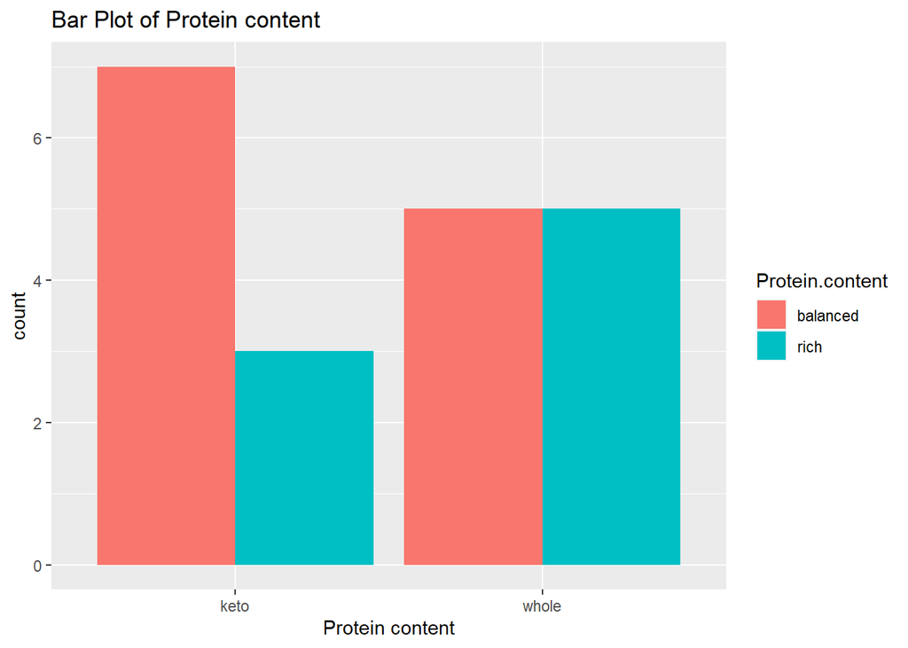

```r
ggplot(data=nutri_new, aes(x=Diet)) +
  geom_bar(aes(fill=Protein.content), position = "dodge") +
  labs(x="Protein content", title="Bar Plot of Protein content")
```

We would like to compare if the protein content (rich or balanced) are same among two diet groups. Based on the plot, “keto” diet has more balanced protein content in the recipe than “whole30” groups. However, we only have 10 recipes in each groups. More samples might be needed if we want to know which diet is more healthier.

##### Histogram of carbohydrates amount (in grams) in two diet groups

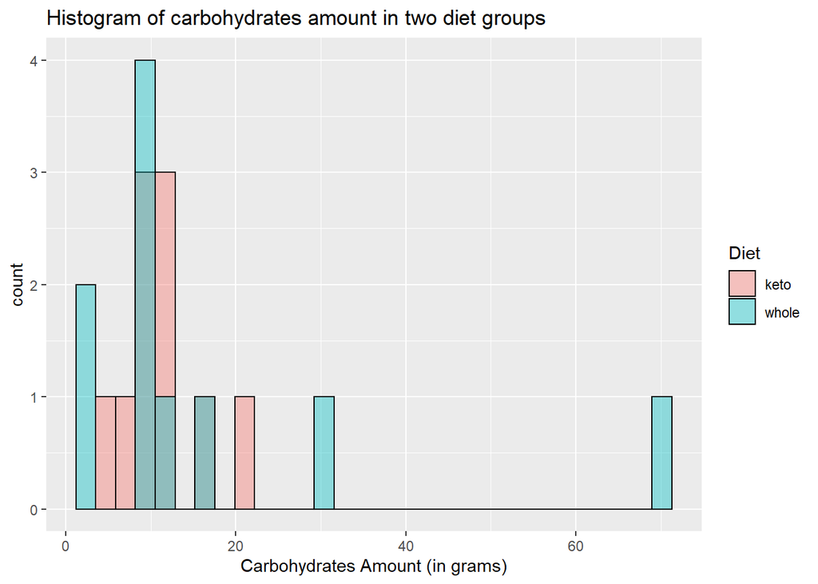

```r
ggplot(nutri_new)+
  geom_histogram(aes(x=Carbohydrates, fill=Diet), colour="black", alpha=0.4, position = "identity") +
  labs(x = "Carbohydrates Amount (in grams)", title = "Histogram of carbohydrates amount in two diet groups")
```

This histogram is for the continuous variable “carbohydrates” in our dataset. We would like to how the amount of carbohydrates are distributed among two diet groups. It looks like most recipes have low carbohydrates in both diet groups, mostly around 10 grams. However, there is one recipe in “whole30” group with high carbohydrates.

##### Box plot of protein amount (in grams) in two diet groups

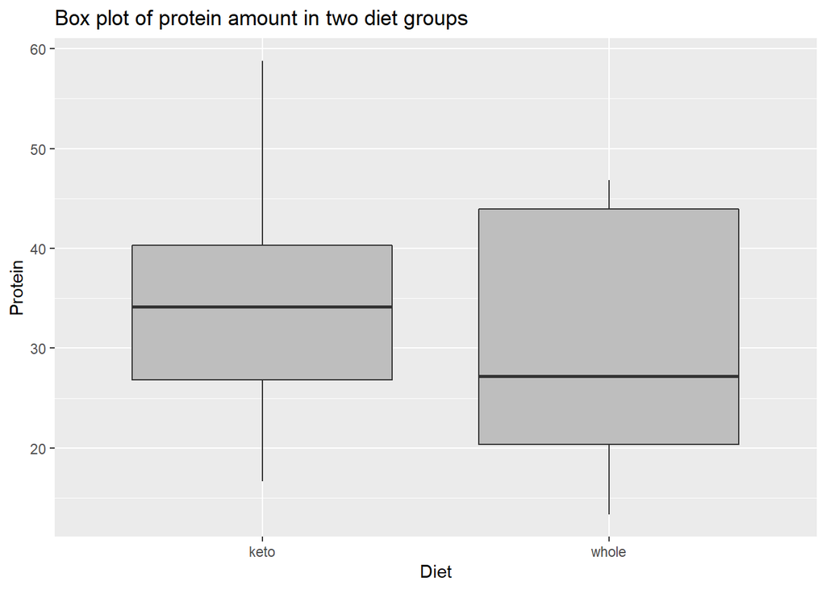

```r
ggplot(nutri_new, aes(x=Diet, y=Protein)) +
  geom_boxplot(fill="grey") +
  labs(title="Box plot of protein amount in two diet groups")
```

This box plot is comparing protein content among two diet groups. The median value of protein is higher in “keto” groups than “whole30” groups. The interquartile range (IQR) is wider for “whole30” group than “keto” group , which indicates more data variability in “whole30” group.

##### Scatter plot of Protein/carbohydrates amount in each recipe of two diet groups

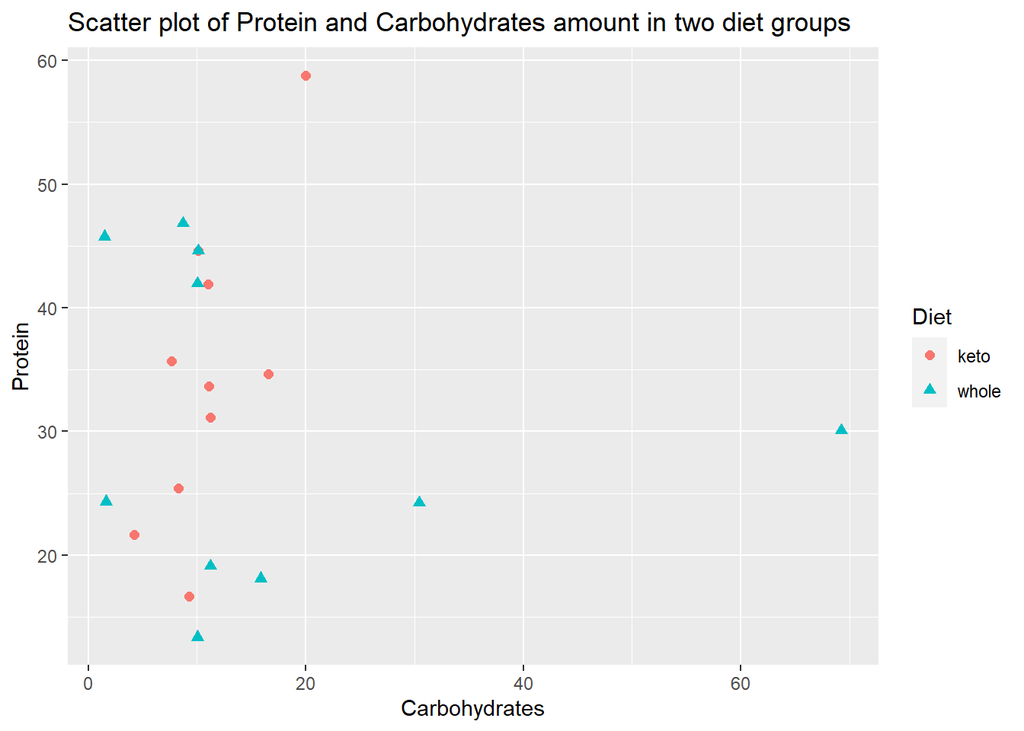

```r
ggplot(nutri_new, aes(x=Carbohydrates, y=Protein, color=Diet, shape=Diet)) +
  geom_point(size = 2) +
  labs(title="Scatter plot of Protein and Carbohydrates amount in two diet groups ")
```

This scatter plot is comparing Protein/Carbohydrates content in each recipe of the two groups. When the Protein/carbohydrates ratio gets too large, it might harm our body since the Protein is too high. We can easily visualize the slope of the points for each diet group, so that we will know which diet might have a higher Protein to Carbohydrates ratio.

### Looking at randomly generated recipes

Using our `random.recipes` function, we can specify how many recipes we want. since these are random, we’re not as able to do something like the comparison between the Keto and Whole30 diets as we just did. We would need to set a seed to get the same recipes each time, or we might just generate two recipes to compare and look at one of the more complex parts of each data, such as recipes.extendedIngredients, which is a “column” in our data that is actually another data frame within it. We will look at a more simple exploration with this function.

#### Summary Tables

The data given whenever we generate our recipes tells us whether the recipe is: vegetarian, vegan, gluten free, dairy free, “very healthy”, cheap, very popular, sustainable, or low FODMAP. We might see how many of our recipes fall into certain groups. For example, how many of our recipes are vegetarian only, dairy free only, both, or neither.

```r
rand <- random.recipes(apiKey = "31bf40952ec14026b2f82b5055fdab93", number=30)
table(Vegetarian=rand$recipes.vegetarian, DairyFree=rand$recipes.dairyFree)
```

```
##           DairyFree
## Vegetarian FALSE TRUE
##      FALSE    13    5
##      TRUE     11    1
```

#### Counts of recipes

We might for example see counts of recipes by the number of servings these recipes yield.

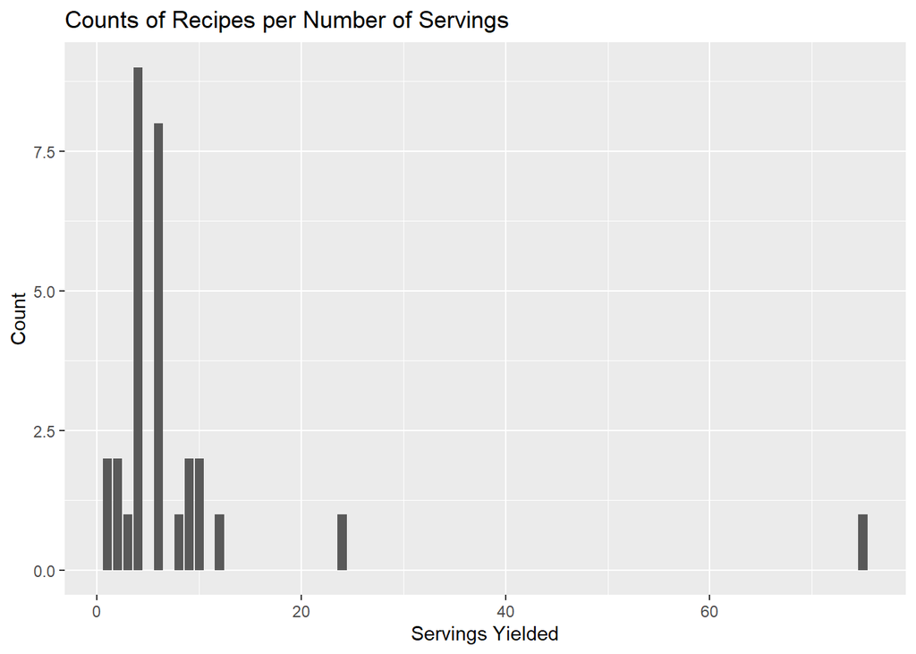

```r
ggplot(rand, aes(recipes.servings)) + geom_bar() +labs(x="Servings Yielded", y="Count", title = "Counts of Recipes per Number of Servings")
```

#### Simple Summaries for numeric data

If following a Weight Watchers diet, we might look at basic summary information of the SmartPoints from these recipes.

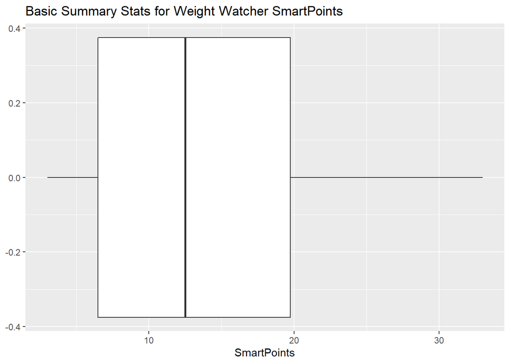

```r
ggplot(rand, aes(recipes.weightWatcherSmartPoints)) + geom_boxplot() + labs(x="SmartPoints", title = "Basic Summary Stats for Weight Watcher SmartPoints")
```

We might even see the spread of total recipe times.

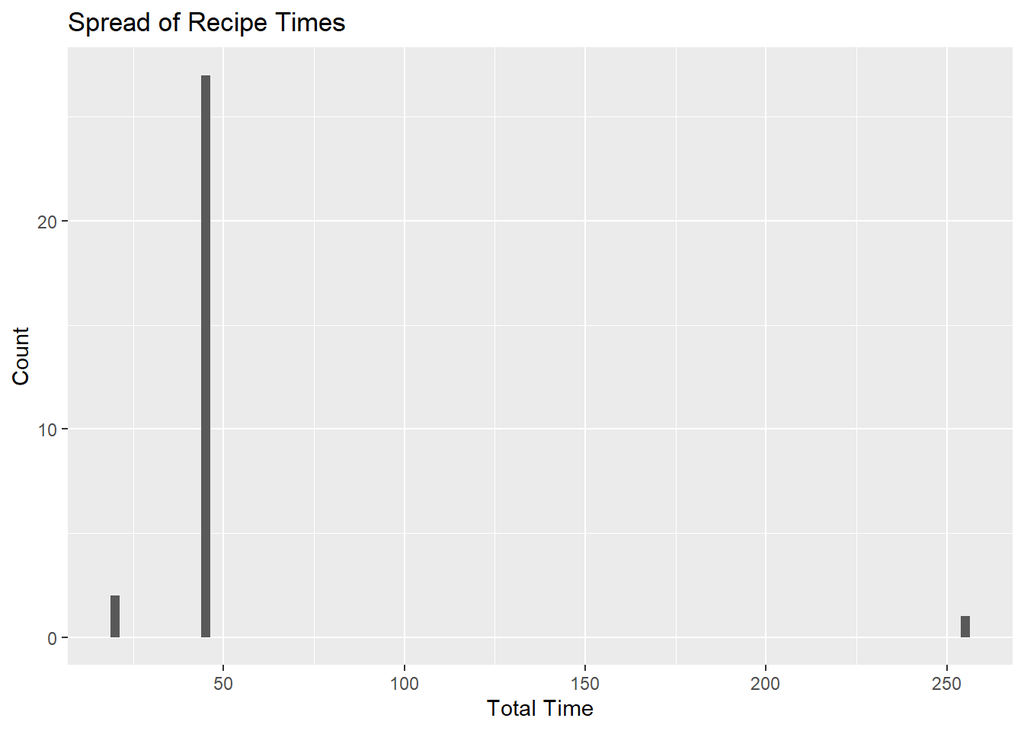

```r
ggplot(rand, aes(recipes.readyInMinutes)) + geom_histogram(binwidth = 2.5) + labs(x="Total Time", y="Count", title = "Spread of Recipe Times")
```

### Restrictions The diet restriction function is more for finding recipes based on diet. If we were to add more options to our function and use them, such as recipe information (`addRecipeInformation=TRUE`) or nutritional information (`addRecipeNutrition=TRUE`, `maxCalories`, `maxFat`, `maxCarbs`, etc.), we would be able to do data analysis much like the Keto vs Whole30 comparison, or the recipe comparison described for the randomly generated recipes.

# Wrap-Up

To summarize what happened in this vignette, we created functions to interact with the Spoonacular Food API, retrieving data from various endpoints, and exploring the data with tables, charts, and plots. We hope the vignette is a useful example in how to connect with an API and ways to explore the data from the what’s retrieved.